# rhosa – Higher-Order Spectral Analysis in R

[figure not shown]

This package aims to provide functions to analyze and estimate higher-order spectra or polyspectra of multivariate time series, such as bispectrum and bicoherence [1].

## Installation

You can install the released version of rhosa from [CRAN](https://CRAN.R-project.org) with:

```r
install.packages("rhosa")
```

Alternatively, the development version from [GitHub](https://github.com/) with remotes:

```r
# install.packages("remotes")
remotes::install_github("tabe/rhosa")
```

## Example

This is a simple example, based on the outline at Figure 1 of [2], which demonstrates how to use rhosa’s functions to find an obscure relationship between two frequencies in some time series imitated by a generative model.

With four cosinusoidal waves having arbitrarily different phases (`omega_a`, `omega_b`, `omega_c`, and `omega_d`), but sharing a couple of frequencies (`f_1` and `f_2`), we define function `D(t)` to simulate a pair of time series: `v` and `w`. We make them noisy by adding an independent random variate that follows the standard normal distribution.

```r
set.seed(1)
f_1 <- 0.35
f_2 <- 0.2
D <- function(t) {
    omega_a <- runif(1, min = 0, max = 2 * pi)
    omega_b <- runif(1, min = 0, max = 2 * pi)
    omega_c <- runif(1, min = 0, max = 2 * pi)
    omega_d <- runif(1, min = 0, max = 2 * pi)
    wave_a <- function(t) cos(2 * pi * f_1 * t + omega_a)
    wave_b <- function(t) cos(2 * pi * f_2 * t + omega_b)
    wave_c <- function(t) cos(2 * pi * f_1 * t + omega_c)
    wave_d <- function(t) cos(2 * pi * f_2 * t + omega_d)
    curve_v <- function(t) wave_a(t) + wave_b(t) + wave_a(t) * wave_b(t)
    curve_w <- function(t) wave_c(t) + wave_d(t) + wave_c(t) * wave_b(t)
    data.frame(v = curve_v(t) + rnorm(length(t)),
               w = curve_w(t) + rnorm(length(t)))
}
```

Both `v` and `w` are oscillatory in principle:

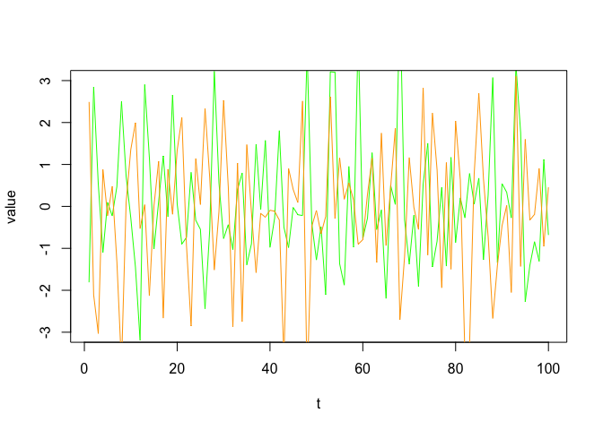

```r
data <- D(seq_len(2048))
with(data, {
    plot(seq_len(100), head(v, 100), type = "l", col = "green", ylim = c(-3, 3), xlab = "t", ylab = "value")
    lines(seq_len(100), head(w, 100), col = "orange")
})
```

v and w.

It is noteworthy that the power spectrum densities of `v` and `w` are basically identical as shown in their spectral density estimation:

```r
with(data, {
    spectrum(v, main = "v", col = "green")
    spectrum(w, main = "w", col = "orange")
})
```

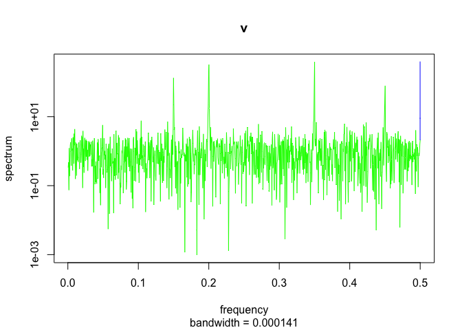

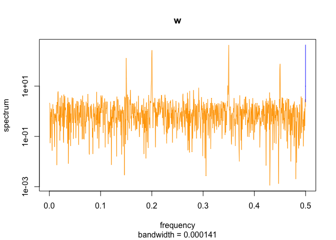

Spectral density estimation via periodograms.

On the other hand, their bispectra are different. More specifically, we are going to see that their bicoherence at some pairs of frequencies are different. rhosa’s `bicoherence` function allows us to estimate the magnitude-squared bicoherence from samples.

```r
x <- replicate(100, D(seq_len(128)), simplify = FALSE)
m_v <- do.call(cbind, Map(function(d) {d$v}, x))
m_w <- do.call(cbind, Map(function(d) {d$w}, x))

library(rhosa)

bc_v <- bicoherence(m_v, window_function = 'hamming')
bc_w <- bicoherence(m_w, window_function = 'hamming')
```

In the above code, we take 100 samples of the same length for a smoother result. The `bicoherence` function accepts a matrix whose column represents a sample sequence, and returns a data frame. Note that an optional argument to `bicoherence` is given for requesting tapering with Hamming [window function](https://en.wikipedia.org/wiki/Window_function).

```r
library(ggplot2)

plot_bicoherence <- function(bc) {
    ggplot(bc, aes(f1, f2)) +
        geom_raster(aes(fill = value)) +
        scale_fill_gradient(limits = c(0, 10)) +
        coord_fixed()
}
```

The axis `f1` and `f2` represent normalized frequencies in unit cycles/sample of range `[0, 1)`. Frequency pairs of bright points in the following plot of `bc_v` indicate the existence of some quadratic phase coupling, as expected:

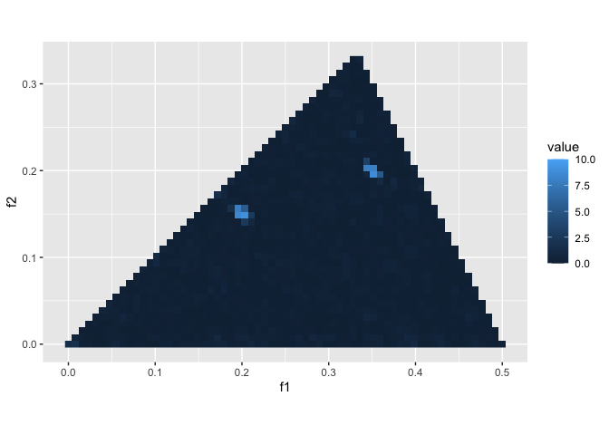

```r
plot_bicoherence(bc_v)
```

v’s estimated magnitude-squared bicoherence.

In contrast, `bc_w` has no peaks at frequency pair `(f_1, f_2) = (0.35, 0.2)`, etc.:

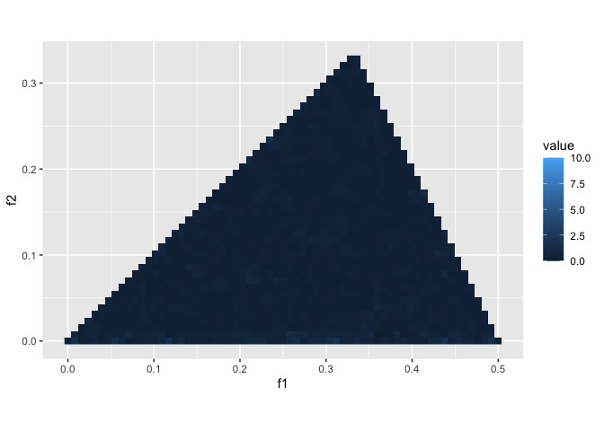

```r
plot_bicoherence(bc_w)
```

w’s estimated magnitude-squared bicoherence.

## License

GPLv3

## Acknowledgement

The author thanks Alessandro E. P. Villa for his generous support to this project.

## References

[1] Brillinger, D. R., & Irizarry, R. A. (1998). An investigation of the second- and higher-order spectra of music. Signal Processing, 65(2), 161–179. https://doi.org/10.1016/S0165-1684(97)00217-X

[2] Villa, A. E. P., & Tetko, I. V. (2010). Cross-frequency coupling in mesiotemporal EEG recordings of epileptic patients. Journal of Physiology-Paris, 104(3), 197–202. https://doi.org/10.1016/j.jphysparis.2009.11.024